# Thermal indices for Cauquenes (Maule, Chile) from WorldClim 2.1

Reproducible thermify case study

# 1 Study area

Experimental window of 20 x 20 km centred on the town of Cauquenes (-35.9671, -72.3225, WGS84), defined in EPSG:32718 and returned as its enclosing geographic extent (-72.4362, -72.2085, -36.0596, -35.8745). The window is an experimental domain around the town, **not** the administrative boundary of the commune. It spans part of the coastal dryland (secano interior) of the Maule Region, where viticulture and other temperate crops depend on both heat accumulation and winter chill.

# 2 Data

WorldClim 2.1 monthly minimum and maximum temperature normals for 1970-2000 (Fick & Hijmans 2017), in degrees Celsius without scale factor. At 2.5 arc-minutes the window contains 36 valid cells; this is too few to represent the relief of the Coastal Range and the valley, so the 30 arc-second product (about 0.9 km) was used. The analysis grid has **672 valid cells**.

Input validation

| check | value | ok |
| --- | --- | --- |
| layers tmin / tmax | 12 / 12 | TRUE |
| layer names (month order) | m01,m02,m03,m04,m05,m06,m07,m08,m09,m10,m11,m12 | TRUE |
| CRS | 4326 | TRUE |
| resolution | 0.00833333 x 0.00833333 | TRUE |
| extent | -72.44167, -72.20833, -36.06667, -35.86667 | TRUE |
| same geometry | TRUE | TRUE |
| value range (degC) | 3.3 to 28.8 | TRUE |
| cells / valid cells | 672 / 672 | TRUE |
| identical NA mask | TRUE | TRUE |
| tmin > tmax (cell-months) | 0 | TRUE |

# 3 Methods

1. **Monthly to daily.** `tmin` and `tmax` were densified independently with pchip_mp (engine: tempify) for the reference calendar year 2023 (365 days), treating the climatology as a closed annual cycle. Monthly means are preserved; the joint consistency check `tmin <= tmax` was enforced.
2. **Daily to hourly.** Hourly temperatures were reconstructed with the linvill model (sine by day, logarithmic decay by night, with astronomical day length at each cell latitude).
3. **Indices.** GDD with bases 5 and 10 degC by average, single_sine, single_triangle, double_sine, double_triangle, hourly; chilling hours 0-7.2 degC (analytical sine and counted on the hourly series); Utah chill units; Dynamic model chill portions.
4. **Periods** (southern hemisphere): heat accumulation 09-01 to 04-30 (crossing the year end of the cyclic climatology); chill accumulation 05-01 to 08-31. The Dynamic model runs continuously through the chill period without monthly resets.

Densification diagnostics (degC): monthly mean error, day-to-day steps at month boundaries and within months, crossings

| variable | max_abs_monthly_mean_error | max_boundary_step | median_boundary_step | max_interior_step | days_tmin_gt_tmax | min_daily_range |
| --- | --- | --- | --- | --- | --- | --- |
| tmin | 0 | 0.2188 | 0.180 | 0.0750 | 0 | 6.7425 |
| tmax | 0 | 0.2614 | 0.217 | 0.1596 | 0 | 6.7425 |

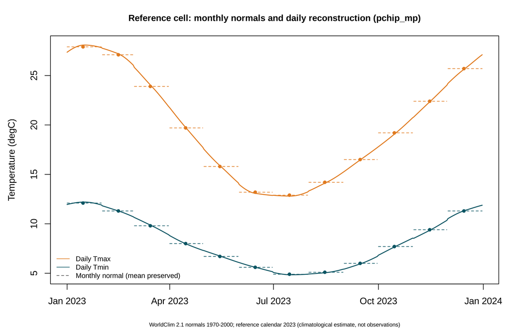

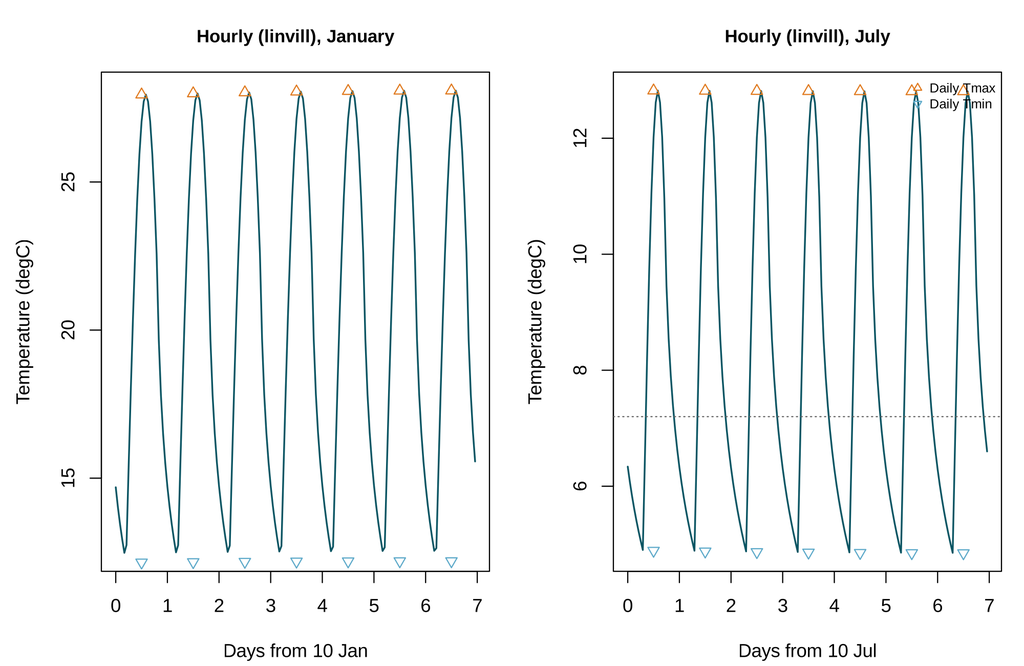

# 4 Results

## 4.1 Reference cell

Reference cell totals

|  | key | aggregation | value | units |
| --- | --- | --- | --- | --- |
| 1 | gdd_average_b5 | season | 2690.4 | degC day |
| 2 | gdd_average_b5 | annual | 3281.2 | degC day |
| 15 | gdd_average_b10 | season | 1480.4 | degC day |
| 16 | gdd_average_b10 | annual | 1520.2 | degC day |
| 29 | gdd_single_sine_b5 | season | 2690.4 | degC day |
| 30 | gdd_single_sine_b5 | annual | 3281.4 | degC day |
| 43 | gdd_single_sine_b10 | season | 1542.0 | degC day |
| 44 | gdd_single_sine_b10 | annual | 1699.9 | degC day |
| 57 | gdd_single_triangle_b5 | season | 2690.4 | degC day |
| 58 | gdd_single_triangle_b5 | annual | 3281.2 | degC day |
| 71 | gdd_single_triangle_b10 | season | 1517.8 | degC day |
| 72 | gdd_single_triangle_b10 | annual | 1642.6 | degC day |
| 85 | gdd_double_sine_b5 | season | 2690.9 | degC day |
| 86 | gdd_double_sine_b5 | annual | 3281.4 | degC day |
| 99 | gdd_double_sine_b10 | season | 1542.1 | degC day |
| 100 | gdd_double_sine_b10 | annual | 1699.9 | degC day |
| 113 | gdd_double_triangle_b5 | season | 2690.9 | degC day |
| 114 | gdd_double_triangle_b5 | annual | 3281.2 | degC day |
| 127 | gdd_double_triangle_b10 | season | 1518.0 | degC day |
| 128 | gdd_double_triangle_b10 | annual | 1642.7 | degC day |
| 141 | gdd_hourly_b5 | season | 2665.3 | degC day |
| 142 | gdd_hourly_b5 | annual | 3194.5 | degC day |
| 155 | gdd_hourly_b10 | season | 1515.6 | degC day |
| 156 | gdd_hourly_b10 | annual | 1642.9 | degC day |
| 169 | ch_sine | season | 827.3 | h |
| 170 | ch_sine | annual | 997.4 | h |
| 183 | ch_hourly | season | 970.0 | h |
| 184 | ch_hourly | annual | 1128.0 | h |
| 197 | cu_utah | season | 1944.5 | chill units |
| 210 | cp_dynamic | season | 92.7 | portions |

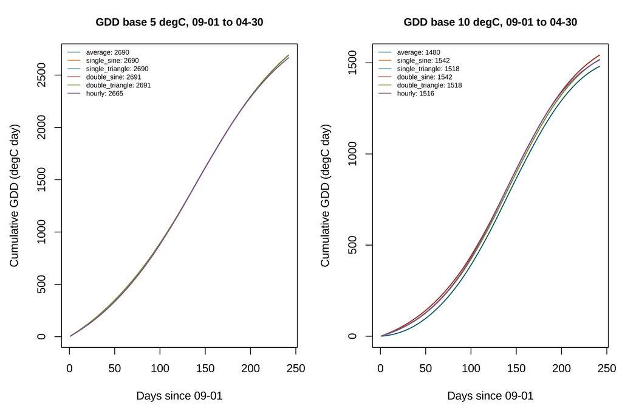

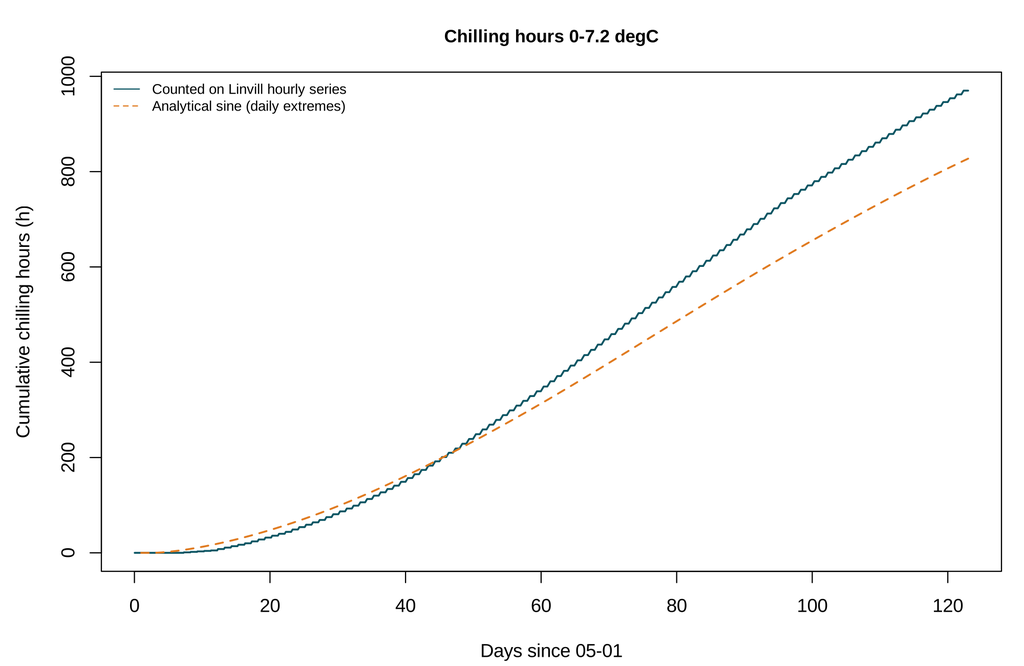

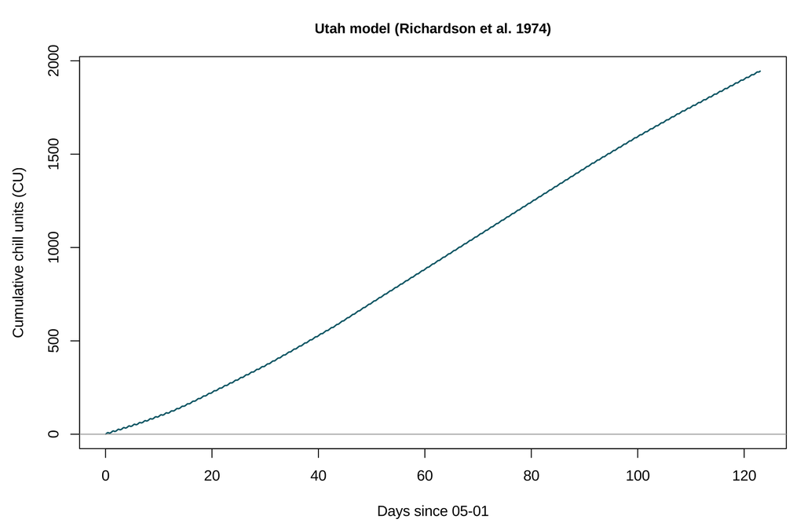

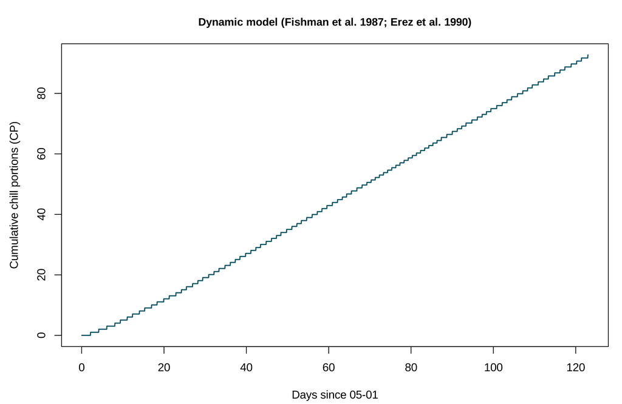

## 4.2 Spatial patterns

Spatial statistics of seasonal totals

| product | units | mean | sd | min | median | max |
| --- | --- | --- | --- | --- | --- | --- |
| gdd_average_b5 | degC day | 2610.0 | 123.9 | 2064.4 | 2645.1 | 2760.0 |
| gdd_average_b10 | degC day | 1400.6 | 122.2 | 881.4 | 1435.1 | 1550.0 |
| gdd_single_sine_b5 | degC day | 2610.1 | 123.8 | 2067.5 | 2645.1 | 2760.0 |
| gdd_single_sine_b10 | degC day | 1469.4 | 113.3 | 1015.4 | 1501.3 | 1611.5 |
| gdd_single_triangle_b5 | degC day | 2610.1 | 123.8 | 2065.5 | 2645.1 | 2760.0 |
| gdd_single_triangle_b10 | degC day | 1443.3 | 115.6 | 969.3 | 1476.7 | 1587.1 |
| gdd_double_sine_b5 | degC day | 2610.6 | 123.8 | 2067.9 | 2645.5 | 2760.5 |
| gdd_double_sine_b10 | degC day | 1469.5 | 113.3 | 1015.5 | 1501.4 | 1611.6 |
| gdd_double_triangle_b5 | degC day | 2610.5 | 123.8 | 2066.0 | 2645.5 | 2760.5 |
| gdd_double_triangle_b10 | degC day | 1443.5 | 115.7 | 969.4 | 1476.9 | 1587.3 |
| gdd_hourly_b5 | degC day | 2585.5 | 123.1 | 2043.6 | 2620.3 | 2734.4 |
| gdd_hourly_b10 | degC day | 1443.9 | 112.0 | 995.0 | 1475.3 | 1584.4 |
| ch_sine | h | 881.9 | 72.4 | 773.7 | 861.3 | 1301.4 |
| ch_hourly | h | 1040.9 | 97.5 | 910.0 | 1007.0 | 1596.0 |
| cu_utah | chill units | 2014.1 | 89.3 | 1935.0 | 1970.0 | 2397.5 |
| cp_dynamic | portions | 93.3 | 1.1 | 91.3 | 93.3 | 96.1 |
| diff_gdd_b10_sine_minus_average | degC day | 68.8 | 10.4 | 59.4 | 65.0 | 134.0 |
| diff_gdd_b10_triangle_minus_sine | degC day | -26.1 | 2.9 | -46.1 | -25.2 | -23.2 |
| diff_gdd_b10_double_minus_single_sine | degC day | 0.1 | 0.0 | 0.1 | 0.1 | 0.2 |
| diff_gdd_b10_hourly_minus_sine | degC day | -25.5 | 1.3 | -27.2 | -26.0 | -20.4 |
| diff_gdd_b5_sine_minus_average | degC day | 0.0 | 0.3 | 0.0 | 0.0 | 3.2 |
| diff_ch_hourly_minus_sine | h | 159.0 | 25.6 | 132.3 | 148.2 | 297.8 |

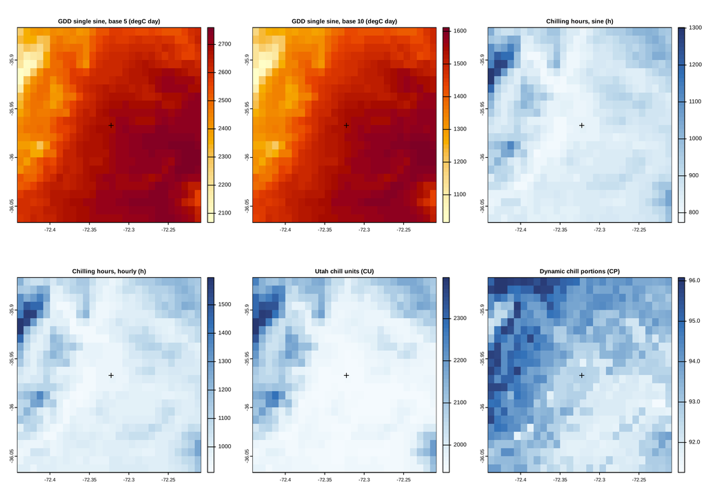

## 4.3 Method comparison

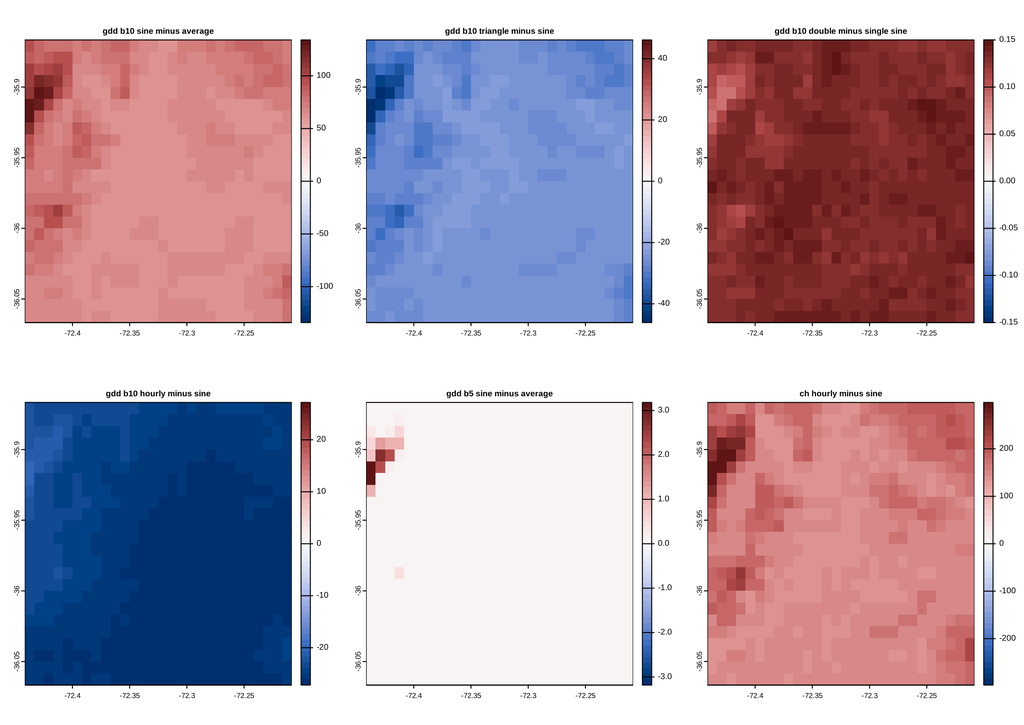

Resolution comparison (30 s vs 2.5 min)

| resolution | product | n | mean | sd | min | p05 | median | p95 | max |
| --- | --- | --- | --- | --- | --- | --- | --- | --- | --- |
| 30s | gdd_single_sine_b10 | 672 | 1469.4 | 113.3 | 1015.4 | 1256.7 | 1501.3 | 1586.9 | 1611.5 |
| 2.5m | gdd_single_sine_b10 | 36 | 1433.5 | 141.1 | 1075.5 | 1149.4 | 1468.3 | 1577.3 | 1589.1 |
| 30s | cp_dynamic | 672 | 93.3 | 1.1 | 91.3 | 91.8 | 93.3 | 95.5 | 96.1 |
| 2.5m | cp_dynamic | 36 | 93.6 | 1.0 | 91.8 | 92.1 | 93.6 | 95.1 | 95.6 |

# 5 Computational performance

Benchmarks (bench::mark medians)

| stage | variant | cells | median_s | per_cell_ms | mem_alloc_mb |
| --- | --- | --- | --- | --- | --- |
| densify | native pchip_mp | 672 | 0.036 | 0.054 | 69.395 |
| densify | tempify pchip_mp | 672 | 1.205 | 1.793 | 21.389 |
| densify | tempify, 1 cell (overhead) | 1 | 0.039 | 39.342 | 0.710 |
| densify | native, 1 cell | 1 | 0.002 | 2.323 | 0.607 |
| gdd (daily, 365 d) | average | 672 | 0.003 | 0.004 | 7.486 |
| gdd (daily, 365 d) | single_sine | 672 | 0.015 | 0.022 | 37.428 |
| gdd (daily, 365 d) | single_triangle | 672 | 0.012 | 0.018 | 37.428 |
| gdd (daily, 365 d) | double_sine | 672 | 0.035 | 0.052 | 85.149 |
| gdd (daily, 365 d) | double_triangle | 672 | 0.027 | 0.040 | 85.149 |
| gdd (daily, 365 d) | hourly (degree-hours) | 672 | 0.339 | 0.505 | 224.659 |
| chill hours (365 d) | sine, analytical | 672 | 0.022 | 0.033 | 56.142 |
| chill hours (365 d) | sine, numerical (1440 steps) | 672 | 16.690 | 24.836 | 9439.067 |
| chill hours (365 d) | hourly count | 672 | 0.146 | 0.217 | 134.747 |
| hourly reconstruction (365 d) | linvill | 672 | 0.905 | 1.347 | 990.587 |
| hourly reconstruction (365 d) | sine | 672 | 0.106 | 0.157 | 233.934 |
| chill period models | utah | 672 | 0.223 | 0.332 | 45.415 |
| chill period models | dynamic | 672 | 0.223 | 0.331 | 396.240 |
| thermify_rast (native) | one block | 672 | 0.980 | 1.459 | 1770.307 |
| thermify_rast (native) | blocks of 50 cells | 672 | 2.512 | 3.738 | 1695.140 |

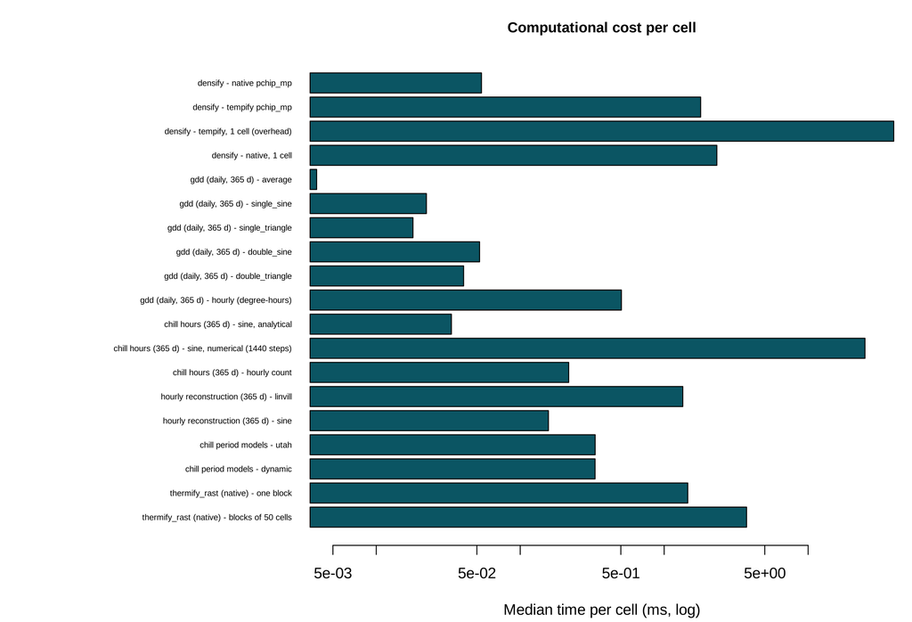

Full spatial workflow time: 7.97 s. Session details are in `session_info.txt`.

# 6 Limitations

- All values are **climatological estimates** from monthly normals, densified and then disaggregated to hours. They are not observations of 2023 and carry two layers of modelling uncertainty: the monthly-to-daily interpolation (which removes day-to-day weather variability) and the diurnal model.
- Smooth daily series lack synoptic variability. Indices that are non-linear in temperature (chilling hours, Utah, Dynamic, GDD near the base) can be biased compared with values computed from observed daily or hourly data.
- The mean-preserving correction produces small steps at month boundaries (see diagnostics).
- Dynamic model portions are completed in discrete steps (a portion is fixed only when the intermediate reaches 1), so the seasonal total of neighbouring cells can differ by up to about one portion for very similar temperatures. Spatial differences of that order should not be interpreted.
- WorldClim interpolation uncertainty is largest in areas with few stations and complex relief.
- This experiment verifies computation and quantifies differences between methods. It is **not an empirical validation**: no method is shown to be more accurate than another. See the validation protocol in the package documentation (`vignette("validation")`).

# 7 Conclusions (methodological)

- Differences between GDD methods are largest for base 10 degC, when daily minima fall below the base; the averaging method then omits heat accumulated in the warm hours.
- Chill estimates depend strongly on the model and on the diurnal reconstruction; they should be compared within a model, not across models.
- Results are reproducible with `Rscript examples/cauquenes/run.R`.

# 8 References

Erez, A., Fishman, S., Linsley-Noakes, G. C., & Allan, P. (1990). The dynamic model for rest completion in peach buds. *Acta Horticulturae*, 276, 165-174.

Fick, S. E., & Hijmans, R. J. (2017). WorldClim 2. *International Journal of Climatology*, 37(12), 4302-4315.

Linvill, D. E. (1990). Calculating chilling hours and chill units from daily maximum and minimum temperature observations. *HortScience*, 25(1), 14-16.

Richardson, E. A., Seeley, S. D., & Walker, D. R. (1974). A model for estimating the completion of rest for Redhaven and Elberta peach trees. *HortScience*, 9(4), 331-332.

Zalom, F. G., et al. (1983). *Degree-days: the calculation and use of heat units in pest management*. UC DANR Leaflet 21373.